# Sentiment analysis of: Ganna et al. Large-scale GWAS reveals insights into the genetic architecture of same-sex sexual behavior

## Introduction

**Disclaimer: sentiment analysis has many limitations.** **For example cannot recognize sarcasm and irony, jokes, and exaggerations**

This is the sentiment analysis of the paper from Ganna et al https://science.sciencemag.org/content/365/6456/eaat7693.

We retrieve all the twitter and news information from altimetric. Altimetric aggregates only the tweets mentioning the paper via direct link to the journal article. Therefore this is not a comprehensive view of all the tweets about the paper. For example we cannot retrieve the comments to a tweet if they don’t include a link to the journal article.

First we load the libraries needed for the anlysis

```r
library(rtweet)
library(ggplot2)
library(tidytext)
library(dplyr)
library(tidyr)
library(lexicon)
library(sentimentr)
library(syuzhet)
library(wordcloud)
library(widyr)
library(igraph)
library(ggraph)
library(stringr)
library(readr)
data("stop_words")
```

## Quick analysis of news articles

The main focus of the analysis is on twitter data, but we also briefly consider news outlets. Just to check the distribution by country.

The article has been covered so far by 377 news outlets.

English-speaking countries are more likely to cover the study (or to include a link to the paper)

Almost no cover of the article in China.

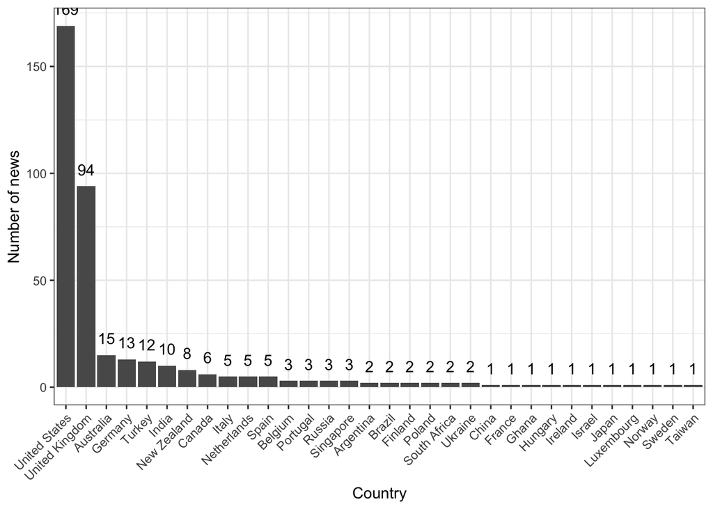

```r
newsoutlets <- read.csv("Altmetric_news_retrieved_2020-01-03.csv")

df <- data.frame(table(newsoutlets$Country))

ggplot(df, aes(x = reorder(Var1, -Freq), y = Freq)) +
  geom_bar(stat = "identity") +
  geom_text( aes(label=Freq), vjust=-1) +
  theme_bw() +
  theme(axis.text.x = element_text(angle = 45,hjust = 1)) +
  ylab("Number of news") +
  xlab("Country")
```

## Download tweets

After setting up a developper tweet account we read the altimetric file containing all the tweets. The altrimetric file contains all the tweet IDs, but not the text. Therefore we need to use the twitter API to download the individual tweets

```r
## read api keys
keys <- read.table("keys.txt",
                   header=F, stringsAsFactors = F)

api_key <- keys$V1[1]
api_secret_key <- keys$V1[2]
access_token <- keys$V1[3]
access_token_secret <- keys$V1[4]

## authenticate via web browser
token <- create_token(
  app = "xxxxxx",
  consumer_key = api_key,
  consumer_secret = api_secret_key,
  access_token = access_token,
  access_secret = access_token_secret)


## Read file with all tweet IDs
ids <- read.csv("Altmetric_tweets_retrieved_2019-12-20.csv",
                colClasses=rep("character",29))
statuses <- c(ids$External.Mention.ID)

## Total number of tweets
length(statuses)
```

```
## [1] 11090
```

## Initial analysis on tweets language and dates

We have 11,090 tweets, but some are in other languages. So we need to check the language and also to check how many are direct tweets, or quotes or retweets. Notice that is not possible to get replies to a tweet. For example, if someone post a tweet with the link to the article and many people comment to it, is not possible to get these comments. The only comments retrieved are those that also cite the paper.

We made the file containing the tweets available: tweets_ganna_et_al_retrieved_2019-12-20.tsv

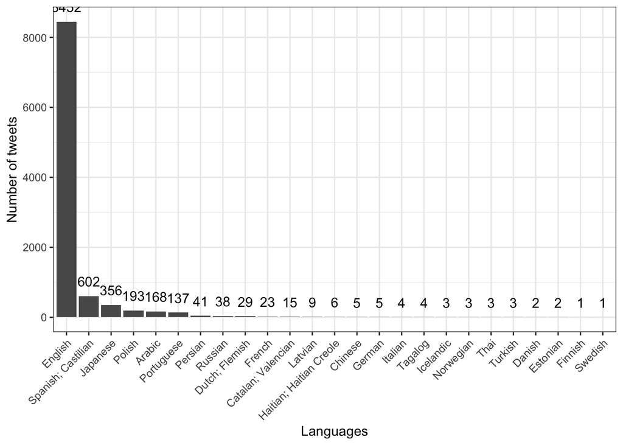

```r
## Get tweets
#tw <- lookup_statuses(statuses)

## Save file with the tweets
#write_tsv(tw %>% select("user_id","status_id","created_at","text","lang","is_quote","is_retweet"),path="tweets_ganna_et_al_retrieved_2019-12-20.tsv")

# Read file saved above
tw <- read_tsv("tweets_ganna_et_al_retrieved_2019-12-20.tsv")

# Plot languages
df <- merge(tw,langs,by.x="lang",by.y="alpha")
df <- data.frame(table(df$english))

ggplot(df, aes(x = reorder(Var1, -Freq), y = Freq)) +
  geom_bar(stat = "identity") +
  geom_text( aes(label=Freq), vjust=-1) +
  theme_bw() +
  theme(axis.text.x = element_text(angle = 45,hjust = 1)) +
  ylab("Number of tweets") + xlab("Languages")
```

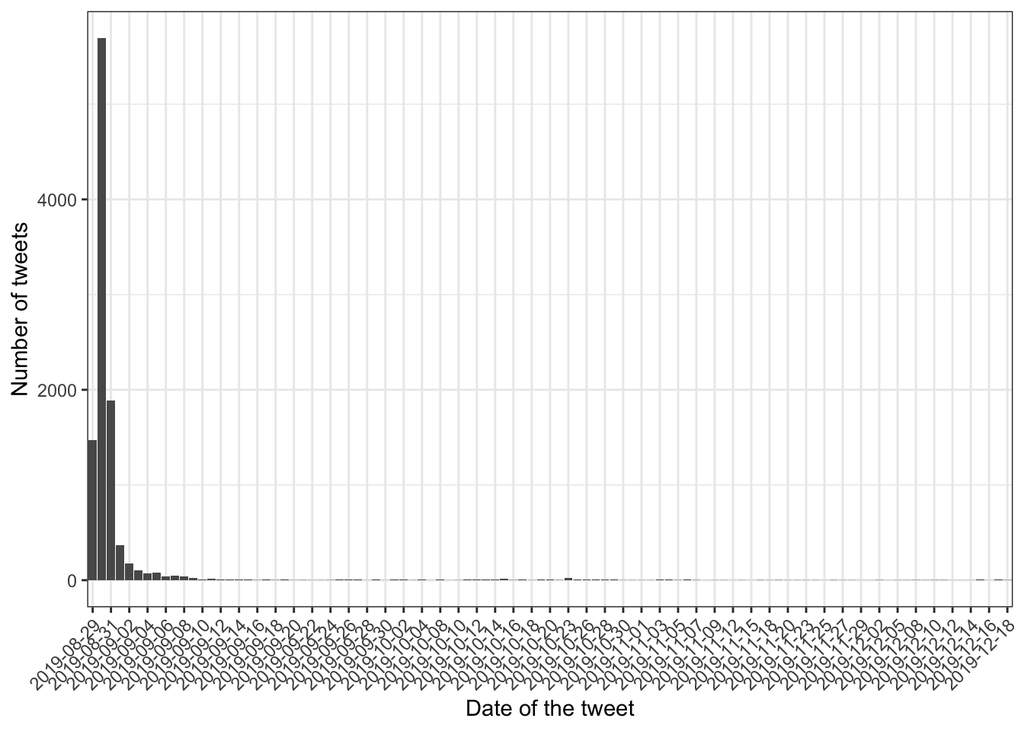

```r
# Plot dates
df <- data.frame(table(as.Date(as.character(tw$created_at))))
df <- df %>% mutate(Var1 = as.Date(Var1)) %>%
  arrange(Var1) %>%
  mutate(Var1f = factor(1:nrow(df)))

ggplot(df, aes(x = Var1f, y = Freq)) +
  geom_bar(stat = "identity") +
  theme_bw() + theme(axis.text.x = element_text(angle = 45,hjust = 1)) +
  ylab("Number of tweets") +
  scale_x_discrete("Date of the tweet",
                   labels=as.character(as.Date(df$Var1[seq(1,length(df$Var1),2)])),
                   breaks=df$Var1f[seq(1,length(df$Var1),2)])
```

## QC of tweet text

We keep only non-retweets because these are not new messages (no new text). We include quotes because these contain new next.

We perform standard QC of the text to remove non-relevant character, usernames, links etc…

```r
## Keep only english language
twen <- tw %>% filter(lang=="en")

## Check number of replies and retweets
table(twen$is_quote) # number of quotes
```

```
##
## FALSE  TRUE
##  7113  1339
```

```r
table(twen$is_retweet) # number of re-tweets
```

```
##
## FALSE  TRUE
##  1814  6638
```

```r
## Exclude retweets
twennort <- twen %>% filter(is_retweet==FALSE)
nrow(twennort)
```

```
## [1] 1814
```

```r
## Data cleaning
wordsqc1 <- twennort %>%
  mutate(text =  gsub("\\s?(f|ht)(tp)(s?)(://)([^\\.]*)[\\.|/](\\S*)", " ", text)) %>% ## Remove urls
  mutate(text =  gsub("@\\S+", " ", text)) %>% ## Remove mentions
  mutate(text =  gsub("@\\S+", " ", text)) %>% # Remove Controls and special characters
  mutate(text =  gsub("\\d", " ", text)) %>% # Remove Controls and special characters
  mutate(text =  gsub('[[:punct:]]', " ", text)) %>% # Remove Punctuations
  mutate(text =  gsub('#\\S+', " ", text)) %>% # Remove Hashtags
  mutate(text =  gsub('\\b+RT', " ", text)) %>% # Remove RT
  mutate(text =  gsub('[[:digit:]]+', " ", text)) %>% # Remove numbers
  mutate(text =  gsub('[\r\n]', " ", text)) %>% # Remove end of lines
  mutate(text =  gsub('[^\x01-\x7F]', " ", text)) %>% # Remove non-ASCII characters
  mutate(text =  str_squish(text))  %>% # Remove extra spaces
  select(text,status_id) %>%
  unnest_tokens(word, text, drop=FALSE) %>% # Tokenize and tolower
  filter(!word %in% tolower(twennort$screen_name)) # remove user names

## Remove stopwords, but not from the text,
## as these might be useful for sentence-level sentiment analysis
wordsqc2 <- wordsqc1 %>%
  anti_join(stop_words)

## Remove words in the title of the paper and some stop words not picked up above
wordsqc3 <- wordsqc2 %>%
  filter(!word %in% c("large-scale", "large", "scale", "gwas", "reveals", "insights",
                      "into", "the", "genetic", "architecture", "of", "same-sex",
                      "same", "sex", "sexual", "behavior", "largescale", "samesex"),
         !word %in% c("https", "t.co", "amp", "im", "isnt", "ive", "arent", "didnt",
                      "theyre", "dont", "youre", "doesnt", "yall")) %>%
  mutate(text =  gsub("largescale gwas reveals insights into
                      the genetic architecture of samesex
                      sexual behavior", "", tolower(text)))
```

Number of final unique words and sentences

```r
length(unique(wordsqc3$text)) # Number of unique tweets
```

```
## [1] 1591
```

```r
length(unique(wordsqc3$word)) # Number of unique words
```

```
## [1] 3410
```

## Most common words and wordcloud

We show the most common words and plot a wordcloud to give a sense of the word composition of the tweets

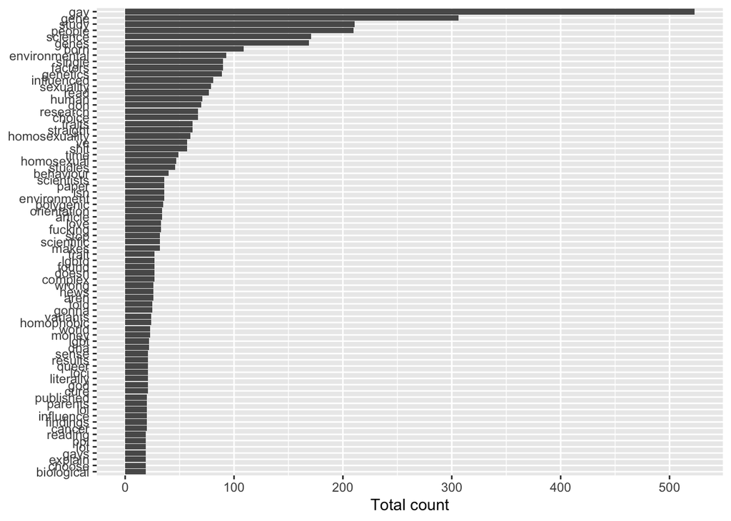

```r
## 70 most common words
wordsqc3 %>%
  count(word, sort = TRUE)  %>%
  top_n(70) %>%
  ungroup() %>%
  mutate(word = reorder(word, n)) %>%
  ggplot(aes(word, n)) +
  geom_col(show.legend = FALSE) +
  labs(y = "Total count",
       x = NULL) + coord_flip()
```

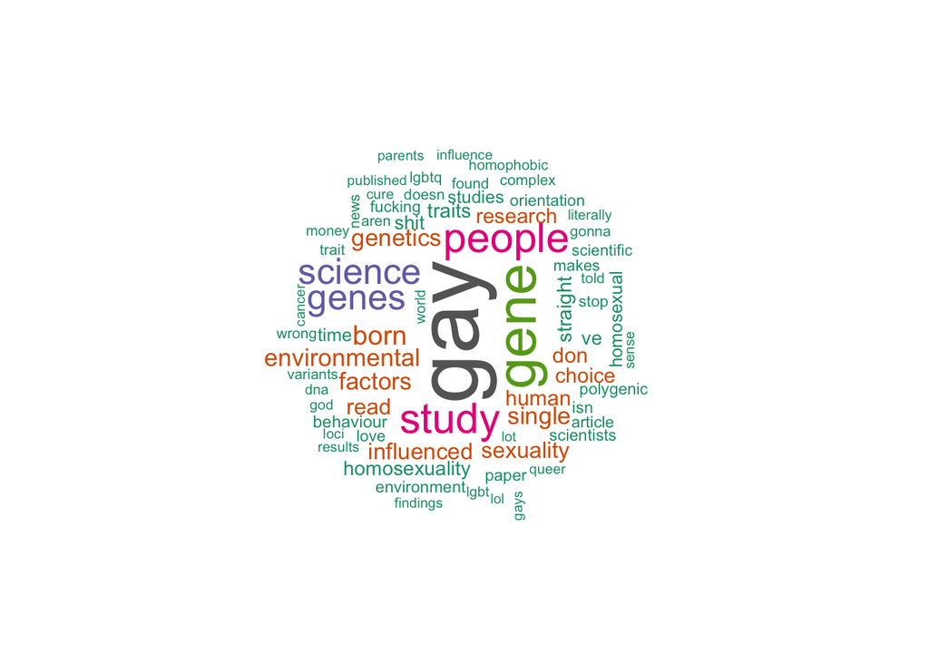

```r
## Wordcloud
pal <- brewer.pal(8,"Dark2")
wordsqc3 %>%
  count(word, sort = TRUE) %>%
  with(wordcloud(word, n, random.order = FALSE, max.words = 70, colors=pal))
```

## Relationship between words

We first identify the correlation between words within the same sentence. The correlation indicates how often two words appear together relative to how often they appear separately.

The high “cure-cancer” correlation reflects several people arguing that scientists should use their time to do most important research (e.g. cure cancer). Same explanation applies to “waste money”.

We also tried topic analysis (LDA), but results are not very informatives (too few words)

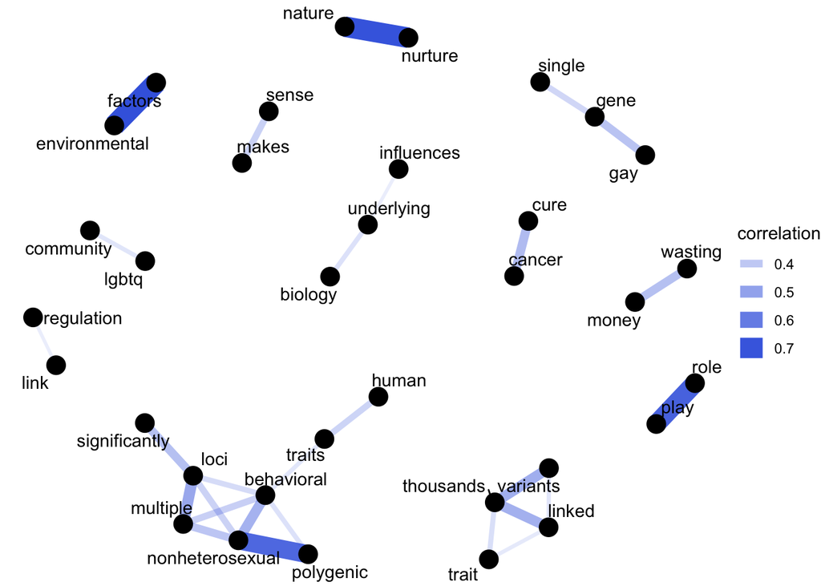

```r
wordsqc3_cors <- wordsqc3 %>%
  group_by(word) %>%
  filter(n() >= 10) %>%
  pairwise_cor(word, status_id, sort = TRUE, upper = FALSE)

set.seed(1234)
wordsqc3_cors %>%
  filter(correlation > .3) %>%
  graph_from_data_frame() %>%
  ggraph(layout = "fr") +
  geom_edge_link(aes(edge_alpha = correlation, edge_width = correlation),
                 edge_colour = "royalblue") +
  geom_node_point(size = 5) +
  geom_node_text(aes(label = name), repel = TRUE,
                 point.padding = unit(0.2, "lines")) +
  theme_void()
```

## Some selected words

We wanted to check how often words like “ethics”, “ethical”, “eugenics” appear and in which context. Most concerns seems to be on “eugenics”, no much tweets are about ethics in the study.

```r
temp <- wordsqc3 %>%
filter(word %in% c("ethics", "ethical"))
print(temp$text, quote=FALSE)
```

```
## [1] for what it s worth this is the latest research on the genetics of homosexuality basically it s complicated like all behavioral genetics but there is an undeniable genetic component sorry if it s behind a paywall not here for an ethical debate
## [2] on the storm front of political and cultural debates or ethical scientists get to explore natural curiosities
## [3] so really this is how we are coming to spend our time trying to find genetic evidence on homosexuality bio ethics folks where are you argh large scale gwas reveals insights into the genetic architecture of same sex sexual behavior science
## [4] fascinating study love how many lgbtstem colleagues involved in this study the collaboration between social and life scientists and the lively debate about the ethics of publishing this research but the graphic
## [5] tl dr horrible ethics like we learnt nothing from exploiting hela cells and honestly this feels like a slap to a lot of natural scientists with critical insight i m also like where s the straight gene and you oop d
## [6] ugh i could write a whole dissertation about the history ethics and implications of finding a gay gene there s a long and problematic history involved in this
## [7] no surprise that the discussion largely leaves out a discussion of ethics while i personally believe this research is productive and necessary when will scientists ever learn that our work has consequences
```

```r
print(nrow(temp)) # Number of tweets containing the word ethics or ethical
```

```
## [1] 7
```

```r
temp <- wordsqc3 %>%
filter(word %in% c("eugenics"))
print(temp$text, quote=FALSE)
```

```
##  [1] this is the study i personally think that trying to find a genetic cause for gayness is incredibly dangerous bc eugenics are always watching over us but anyways like anything humans do its genetical component is polygenic
##  [2] i personally think scientists investigating this are violent and most likely motivated by eugenics
##  [3] this idea of locating evidence of social difference in biology is built upon eugenics race science which furthermore creates a gateway of severe dehumanization oof lol
##  [4] nyuuuhhhhhhhhhhhhhhhhhhh why does good science keep getting in the way of all the eugenics all these weirdos have obviously wanted to do for the last three decades
##  [5] this is fucking eugenics and pseudoscience you re gonna get people killed
##  [6] the search for the gay gene is a preamble to eugenics
##  [7] i used to be really curious about the specific genetic mechanics of queerness but considering the current state of the world i d rather we not do any research on the subject we seem really ready to give that whole eugenics thing yet another go right now
##  [8] eugenics incoming
##  [9] this fevered search for the gay gene is just a load of assholes attempting to eugenics gay people out of existence if we keep allowing this path of research to proceed the elites of the world will genetically tailor and oppress people from before birth
## [10] from the first i heard of this supposed gay gene s and right through its normalisation to born this way i have hoped it would be proven wrong i know the history of prejudice eugenics too well to think attributing nonheteronormative sexualities to genes will end well
## [11] fuck eugenics
## [12] when will people realise testing for a gay gene is just the first step in eugenics
## [13] there is no single gay gene all my genes are queer baby they ve been dancing to prince ever since i was born and will carry on till i die and i suspect in the next lives too now let me tell you where this attempt at eugenics can be shoved
## [14] people love biological essentialism and eugenics
## [15] full offense but i wish we never researched this bc as a society we arent ready to know any biological factors pf being gay since eugenics is still alive and well
## [16] good to know science magazine was lookin into eugenics studies i guess
```

```r
print(nrow(temp)) # Number of tweets containing the word eugenics
```

```
## [1] 16
```

## Sentiment analysis

We tried three approaches. They were selected because perform best in this comparison: https://paulvanderlaken.com/2017/12/27/sentiment-analysis-lexicon-quality/

All these methods use dictionaries of words pre-assigned to “positive”, “negative” or “neutral” sentiment. The first two methods also consider the sentence context (e.g. negation).

For each method we report the histogram, the distribution of the sentiment scores and the top 20 sentences with largest score (the score is printed ahead of the sentece, a positive score means an inferred positive comment, a negative score an inferred negative comment)

**Disclaimer: sentiment analysis has many limitations** **For example cannot recognize sarcasm and irony, jokes, and exaggerations**

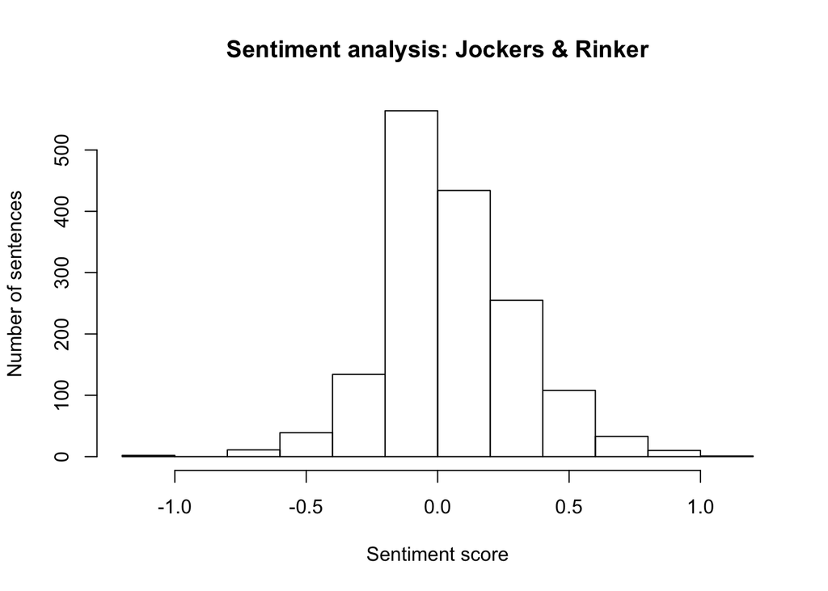

```r
setn <- get_sentences(as.vector(unique(wordsqc3$text)))

# Jockers dataset
s1 <- sentiment(setn,polarity_dt = lexicon::hash_sentiment_jockers)
hist(s1$sentiment, main="Sentiment analysis: Jockers & Rinker",
     xlab="Sentiment score",
     ylab = "Number of sentences")
```

```r
summary(s1$sentiment)
```

```
##     Min.  1st Qu.   Median     Mean  3rd Qu.     Max.
## -1.11267 -0.01741  0.02294  0.06993  0.20412  1.10000
```

```r
s1_out <- s1 %>% mutate(text=as.vector(unique(wordsqc3$text))) %>%
  arrange(desc(abs(sentiment))) %>%
  head(n = 20L)
print(paste0(round(s1_out$sentiment,2), ": ", s1_out$text), quote=F)
```

```
##  [1] -1.11: we been knew but the dumbass genpop are gonna misinterpret this anyway i hate people i really hate people
##  [2] 1.1: hey bro who cares if your gay your gay straight straight bi asexual trans who cares if it s nature or nurture love is love
##  [3] -1.01: fucking shock er
##  [4] 1: so lgbtq folks have really interesting and complex genes cool
##  [5] 0.99: pretty much confirms common knowledge genes that aren t advantageous for reproduction usually don t survive thousands of years but the mix makes sense ofcourse and is extremely common for most behavioral traits anyway but who cares they are humans like everyone else
##  [6] 0.94: oh wow this is really a groundbreaking discovery
##  [7] 0.94: my understanding is that this was the general consensus among the scientific community for a few years now study was handled quite well but will be interested in seeing the headlines effect on the general public
##  [8] 0.93: this is certainly interesting and undoubtably well put together
##  [9] 0.92: yes but can we cure it
## [10] 0.87: pretty interesting thread
## [11] 0.82: working on acquiring more gay genes to increase my gaynome
## [12] 0.82: new study confirms that same sex love is natural while the heterosexual lifestyle is indubitably a choice and here i preferred to think of myself among the autonomous agents i jest
## [13] 0.8: translation there is virtually no genetic association or a very loose polygenic association environment nurture plays major role but please keep telling year olds that they may be gay and that it s super cool
## [14] -0.78: excuse me what the fuck
## [15] 0.78: fascinating work excited to read
## [16] 0.78: hmmmmmmmmmmmmmmmmmm very interesting
## [17] 0.78: very interesting read
## [18] 0.77: interesting strong relationship between nature vs nurture
## [19] 0.76: okie dokie fascinating stuff really stories like this tend to bring out queerphobic people and tends to add add fuel to their dramatics but still fascinating stuff
## [20] -0.75: shocking
```

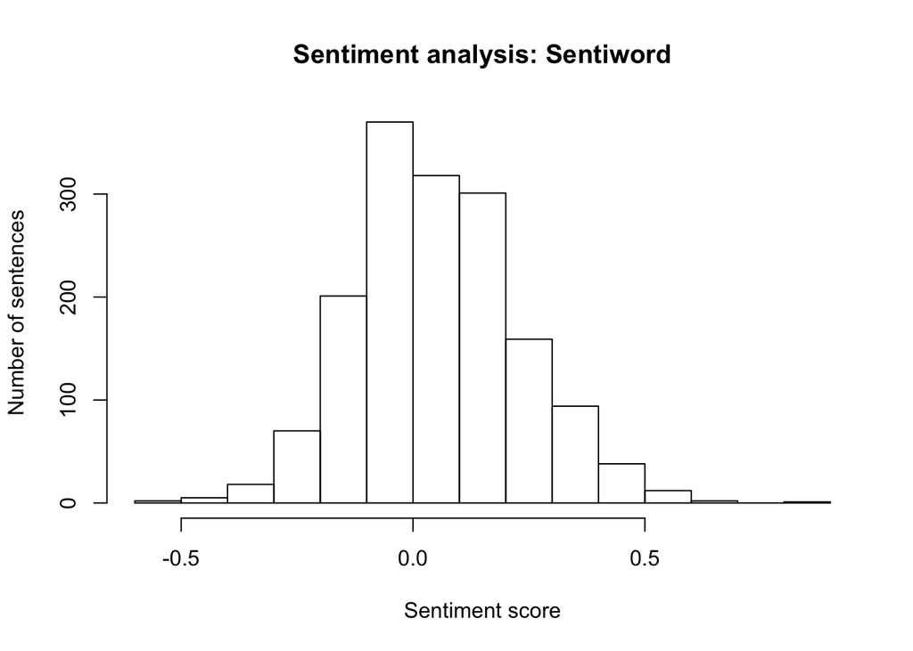

```r
# Sentiword
s1_sentiword <- sentiment(setn, lexicon::hash_sentiment_sentiword)
hist(s1_sentiword$sentiment, main="Sentiment analysis: Sentiword",
     xlab="Sentiment score",
     ylab = "Number of sentences")
```

```r
summary(s1_sentiword$sentiment)
```

```
##     Min.  1st Qu.   Median     Mean  3rd Qu.     Max.
## -0.57855 -0.05067  0.04419  0.05755  0.16667  0.81963
```

```r
s1_out_sentiword <- s1_sentiword %>%
  mutate(text=as.vector(unique(wordsqc3$text))) %>%
  arrange(desc(abs(sentiment))) %>%
  head(n = 20L)
print(paste0(round(s1_out_sentiword$sentiment,2), ": ", s1_out_sentiword$text), quote=F)
```

```
##  [1] 0.82: okie dokie fascinating stuff really stories like this tend to bring out queerphobic people and tends to add add fuel to their dramatics but still fascinating stuff
##  [2] 0.69: but what about the gay freckle
##  [3] 0.68: good detailed study still with limitations but far better than any earlier study hopefully this will discourage further poor quality studies in human behavioural genetics
##  [4] 0.58: someone took the time to study this we ve no cure for dementia aids cancer leukaemia but luckily we ve got our best guys studying the gay gene
##  [5] -0.58: ah yes the two sexualities green legs blue and white circle and black legs grey semicircle head
##  [6] 0.56: i do hope you realise that headlines like these attract only the attention of homophobic heterosexuals who will not bother to read the article instead just use the first sentence to prove their being gay is a choice argument
##  [7] 0.54: why are people looking for a gay gene can we put more time and effort into ways to protect and respect the lgbtq community instead of pointlessly analysing us
##  [8] 0.54: so homosexuality is entirely natural is basically your headline
##  [9] 0.54: with all due respect it is disingenuous to proclaim that god made you gay when there is zero scientific evidence to back that up in fact there is ample evidence to the contrary check out one of the latest studies on this subject
## [10] 0.53: big waste of time nothing to see here hears this report on nothing on yesterday how about reporting on something worthwhile like lousy health outcomes in the u s
## [11] 0.53: gay gene gay gene my gay uncle gene
## [12] 0.52: people who add being gay is a choice literally know nothing on how genes work
## [13] 0.52: pretty sure the gay gene is yankee pinstripes
## [14] -0.51: nibbas were really trying to inflict gay
## [15] 0.51: some girls like girls just because life and stuff nicely done there detectives queer folx coulda told ya that without the poking and prodding and pathologizing but okay
## [16] 0.5: i love being right quick disclaimer this doesn t mean gay people aren t worthy of the same level of respect dignity and life as all of us
## [17] 0.5: gay is a choice amen
## [18] 0.5: so we all gay
## [19] 0.5: a lot of y all owe heterosexuals an apology cuz y all was tryna get off the people can be born gay agenda
## [20] 0.49: is some arsehole looking for a cure that lab time and research could be put to far better use
```

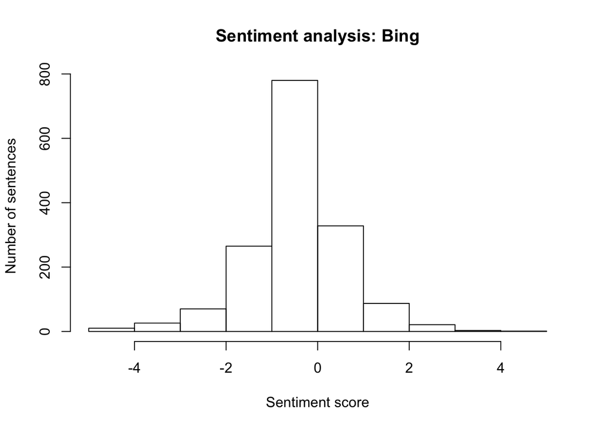

```r
# Bing
s1_bing <- get_sentiment(as.vector(unique(wordsqc3$text)), method="bing")
hist(s1_bing, main="Sentiment analysis: Bing",
     xlab="Sentiment score",
     ylab = "Number of sentences")
```

```r
summary(s1_bing)
```

```
##    Min. 1st Qu.  Median    Mean 3rd Qu.    Max.
## -5.0000  0.0000  0.0000  0.0352  1.0000  5.0000
```

```r
s1_out_bing <- data.frame(s1_bing) %>%
  mutate(text=as.vector(unique(wordsqc3$text))) %>%
  arrange(desc(abs(s1_bing))) %>%
  head(n = 20L)
print(paste0(round(s1_out_bing$s1_bing,2), ": ", s1_out_bing$text), quote=F)
```

```
##  [1] -5: ipsc incredibly problematic scientific crap ipsc idiotic persecution scientifically created ipsc inane puerile sadistic content if you hate ipscs you too could join my lab ipsc giladlab andpee
##  [2] 5: i love being right quick disclaimer this doesn t mean gay people aren t worthy of the same level of respect dignity and life as all of us
##  [3] -5: ultimately this wasteful study is trying to point out whether being gay is a choice or not listen you fucking heteros even if it is a choice i d still pick gay enough of this passive aggressive attack on homosexuality and maybe spend some time curing cancer
##  [4] -5: people being absolutely enraged over this research being done as if every scientist does the same research god forbid any research is done besides working on curing cancer obnoxious and bitter people everywhere
##  [5] -4: i cannot believe you would outright lie about this study it s appalling for someone who claims to be a christian leader to be so blatantly dishonest from the study itself same sex sexual behavior is influenced by not one or a few genes but many
##  [6] -4: hmmmmmmmmmmmmm i take issue with you framing it as gay gene vs no gay gene that s conservative bias now excuse me i m going to go to the other room because of my walking gene
##  [7] -4: too bad i was kinda hoping there was so we could really help out the gay agenda by threatening to put the gene into homophobes to make them gay would have scared the shit out of them gayagenda wewillcuddleallyourpets wewillputrainbowsoneverything
##  [8] -4: as usual i ll be slightly more direct this is junk science done by reckless ego driven data miners it serves no purpose aside from ego padding and has the potential to do tremendous harm also is dangerous
##  [9] 4: amazing to see the study was preregistered and they even created a dedicated website for the public to understand the results on such a sensitive subject that s what i call great science openscience preregistration
## [10] -4: either way it doesn t really need an explanation it doesn t need justification whatever makes us lgbtqi is irrelevant nobody would choose to live a life made more difficult by societal values and archaic laws just accept that we are here we are queer and we are people
## [11] 4: i find this incredibly fascinating however with the fragility of homosexual rights should we really be researching into this when there are people out there that would like to cure us
## [12] -4: surprise surprise there is no gay gene bergoglio false prophet of the apocalypse stop telling people they are born this way and affirming them in a sin that cries out for god s vengeance catholictwitter
## [13] 4: wow this genuinely surprises me as someone that supports the they are born that way argument this is intriguing interesting
## [14] -4: before i see a single queer on here saying no shit and railing against this study being done let me just start by saying you have to invalidate a false claim with fact based empirical research
## [15] -3: not one but many which genes are activated are influenced by social factors and biological factors this means being gay is most likely a response to trauma of some sort be it rape or lack of a parental figure and so on
## [16] 3: while it s tempting to point out holes in this study i think scientist should resist this study pushes a narrative that is not a good framework for pushing cultural acceptance of people who are not like me nor why i am this way
## [17] -3: interpretation if you don t like gays you ll use the word science in crazy irrelevant ways as you struggle to prop up your bias with pseudo rational blather just trying to encourage you in your journey not hurt your feelings
## [18] -3: why are they even looking for a gay gene why don t they go and investigate people are who really unpleasant to lgbt people and find out what their fucking problem is
## [19] -3: whats that tehres no universal cause next youll be saying trans isn t a disorder and intersex folk should have there genitals mutilated angry sarcasm fyi
## [20] -3: the commentary on this article is another sad example of how poor scientific literacy is in the general public poor journalistic writing by news organizations on science only compounds the problem
```